# LTOM.01.002 Data Analysis in Community Ecology

Carlos P. Carmona (carlos.perez.carmona@ut.ee)

Aurele Toussaint (aurele.toussaint@ut.ee)

Meelis Pärtel (meelis.partel@ut.ee)

Diego P. F. Trindade (diego.trindade@ut.ee)

Slendy Rodriguez-Alarcon (slendy.rodriguez@ut.ee)

Autumn 2023

# 4 Scripts and data in R

## 4.1 Working directory

In which folder (working directory) you have your files?

```r
wd=getwd() # get working directory
wd
```

```
## [1] "C:/Users/Carlos Perez Carmona/Dropbox/Courses/DataAnalysisCommunityEcology/2023-2024/Data"
```

```r
setwd("C:/Users/Carlos Perez Carmona/Dropbox/Courses/DataAnalysisCommunityEcology/2023-2024/Data") # change to your favorite folder!
dir() # lists files
```

```
##  [1] "basal_area.R"      "bry.tab.txt"       "climate.txt"
##  [4] "clusters.rda"      "community.rda"     "coordinates.txt"
##  [7] "Data.Rproj"        "droughtnet.txt"    "eesti reljeef.DAT"
## [10] "eesti reljeef.ID"
##  [ reached getOption("max.print") -- omitted 26 entries ]
```

Sometimes it is needed to give double backslashes: `"c:\\mp\\doc\\"`

## 4.2 Keeping track of objects in the memory, saving R objects

You can check what objects you currently have and remove unnecessary.

```r
# Making some objects
a=3
diversity=c(18,27,10,22,25,8,12)
soil.ph=c(4.5,6.4,3.9,5.3,5.9,3.2,4.2)
soil.type=c("mineral","mineral","peat","mineral","mineral","peat","peat")

ls()
```

```
## [1] "a"         "diversity" "rootDir"   "soil.ph"   "soil.type" "wd"
```

```r
ls.str() # more information
## a :  num 3
## diversity :  num [1:7] 18 27 10 22 25 8 12
## rootDir :  chr "C:/Users/Carlos Perez Carmona/Dropbox/Courses/DataAnalysisCommunityEcology/2023-2024/Data"
## soil.ph :  num [1:7] 4.5 6.4 3.9 5.3 5.9 3.2 4.2
## soil.type :  chr [1:7] "mineral" "mineral" "peat" "mineral" "mineral" "peat" "peat"
## wd :  chr "C:/Users/Carlos Perez Carmona/Dropbox/Courses/DataAnalysisCommunityEcology/2023-2024/Data"

save(diversity,soil.ph,soil.type,file="my.data.Rda") # saving so tahat R can use later
## NB! Other software cannot read these files!

rm(diversity,soil.ph,soil.type) # removes objects not needed
ls()
```

```
## [1] "a"       "rootDir" "wd"
```

```r
load("my.data.Rda") # loads what has been saved in R
ls()
```

```
## [1] "a"         "diversity" "rootDir"   "soil.ph"   "soil.type" "wd"
```

> Explore with `?rm` how to remove all objects in the memory. WARNING, use carefully!

**Answer**

```r
# currently we can still use this. Sometimes it is good to start your session with that expression
rm(list=ls())

# We now need to load our saved data again:
load("my.data.Rda")
```

## 4.3 Creating own scripts

Scripts are just text files with codes. In RStudio you can add new R Script file. When saving, use extension `.R`, for example `my_first_script.R`

Add comments for your own, and for others with `#` mark

Run your script by highlighting a part and then Cntr+Enter (=run!)

```r
## My script, autumn 2019

# a is a variable ....
a = 5

print("Hello! This is my first script")
```

```
## [1] "Hello! This is my first script"
```

```r
## end of my script
```

> Save the text above to a text file with name “my_first_script.R”.

Now we can call the same script.

```r
a=NA
a
```

```
## [1] NA
```

```r
source("my_first_script.R") # runs your script from the file
a # a has been defined in the script!
```

[output not shown]

## 4.4 Conditions in scripts

Does something only if conditions are fulfilled. The proportion of script for which the condition applies can be given between special parentheses `{` and `}`

```r
soil="peat" # try to change to "mineral"

if (soil=="peat") {      # commands for conditions are between {}
  print("Has been wet")
}
```

```
## [1] "Has been wet"
```

```r
answer=ifelse(soil.type=="peat","wet","dry") # conditions, if true, if not
print(answer)
```

```
## [1] "dry" "dry" "wet" "dry" "dry" "wet" "wet"
```

> Use function `ifelse` with `plot` to have scatterplot between `soil.ph` and `diversity` and select symbol colors depending on `soil.type`

**Answer**

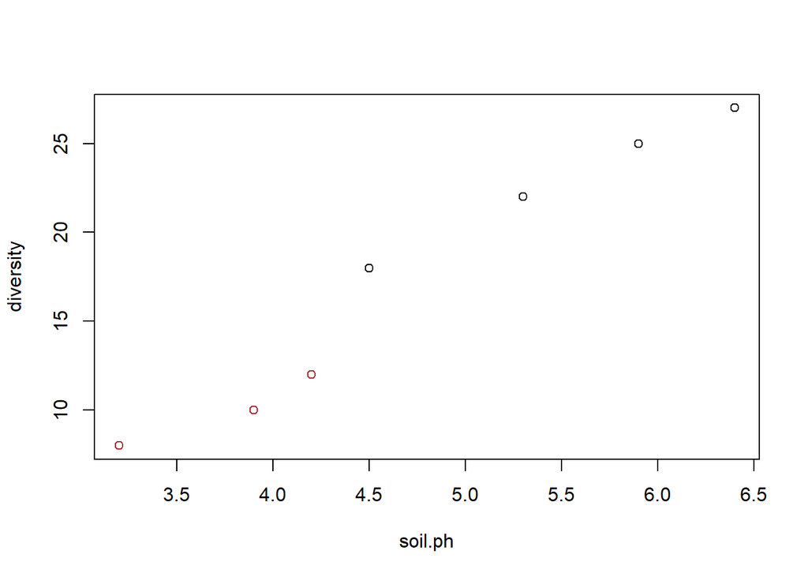

```r
plot(soil.ph,diversity,col=ifelse(soil.type=="peat","brown","black"))
```